# Junnan

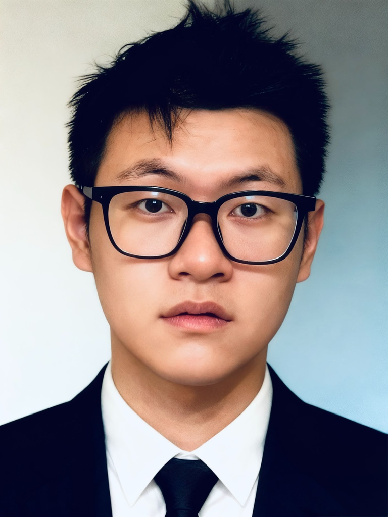

Junnan Lyu(Junnan)

junnanl18@g.ucla.edu

4th-year undergraduate student at Data Science & Statistics Insitute

University of California, Los Angeles

### **Education:**

B.S. in Data Science & Statistics, 2026

[University of California, Los Angeles](https://statistics.ucla.edu/)

Transfer Computer Science 2025

[Mt.San Antonio College](https://sites.google.com/student.mtsac.edu/anthonytelles/mt-sac)

### Junnan Lyu (Junnan)

📧 junnanl18@g.ucla.edu  
4th-year undergraduate student  
Data Science & Statistics Institute  
University of California, Los Angeles

#### Education

**B.S. in Data Science & Statistics**, 2026  
[University of California, Los Angeles](https://www.ucla.edu)

**Transfer in Computer Science**, 2025  
[Mt. San Antonio College](https://www.mtsac.edu)

## About Junnan

Hi, I’m Junnan, an undergraduate in Data Science & Statistics at UCLA.

My life has been shaped by turning points and restarts—from moving between cities in childhood, to switching from humanities to STEM, to restarting my college path in the U.S.

At community college, I rebuilt from zero: I founded the Math Club, organized competitions, and served as a Student Services Senator, graduating with a 3.97 GPA.  
This led me to UCLA, where I now maintain a 3.7 GPA while pursuing my passion for statistics, data science, and machine learning.

Through two ongoing research positions, I apply data methods in medicine, the social sciences, and advanced machine learning.  
Each experience deepens my interest in data-driven research and strengthens my goal of continuing to graduate study in data science and statistics.

## Research Interests

- Applied Statistics & Machine Learning
- Data Science for Medicine & Health
- Statistical Computing
- LLM and ML

## My LinkedIn

[My LinkedIn](https://www.linkedin.com/in/junnan-lyu-873a99263/)